# Notebook Setup

```python
# Optional Google Drive Setup
import os
from google.colab import drive
drive.mount('/content/dir', force_remount=True)
```

```python
cd '/content/dir/MyDrive/4152 5152 Group Work'
```

```
/content/dir/MyDrive/4152 5152 Group Work
```

```python
import os
import cv2, uuid, random
import numpy as np
import pandas as pd
import tensorflow as tf
from google.colab.patches import cv2_imshow
from scipy import ndimage
from utils import Filters
import SpeedLimitCNN

print(os.listdir('/content/dir/MyDrive/4152 5152 Group Work'))

%pylab inline
```

```
['Stage 2 - Writeup Template.gdoc', 'data', 'utils', 'models', 'Model Template.ipynb', 'SpeedLimitCNN.py', '__pycache__', 'SpeedLimitRecognition.ipynb', 'Stage 3.ipynb', 'Stage 4.ipynb']
```

# Model

## Description:

Our model is a relatively simple CNN designed to determine the speed limit on a road given an image of the speed limit sign. The model was trained on images of U.S. speed limit signs but could work for others as well.

```python
model = tf.keras.models.load_model('models/SpeedLimitCNN_Acc-90pct.model')
```

## Structure

Each convolutional layer was given 32 3x3 filters/kernels to train. While the max pool layer uses a 4x4 kernel and the average pool layer uses a 3x3 kernel.

**Each hidden layer following has a factor of $ \frac{1}{2}x\ $, $ \frac{1}{4}x\ $, $ \frac{1}{8}x\ $, neurons respectively**. The idea behind this was to allow the network to slowly converge onto a feature set it finds best for classifying the images as the feature map is passed through the MLP. The reason for making them $ \frac{1}{2}\ $, $ \frac{1}{4}\ $, and $ \frac{1}{8}\ $ is to help maintain the power-of-2 nature of the model's design. The theory behind this is that computers work soley in powers of 2 and maintaining this across the network structure could allow for quicker and more efficient operations at the hardware level. Thus, eventually relaying some of this increase in efficiency to the model's training perfomance. *In theory.*

**Loss Function**

Catergorical Cross-Entropy was chosen because it provides a relative ratio of classified/misclassified labels in a multi-label classification task. Basically, it's a metric that represents how many samples of each class are labelled correctly/incorrectly relative to the entire training set.

Each class can be thought of as a 'category'

```python
model.summary()
```

```
Model: "sequential"
_________________________________________________________________
 Layer (type)                Output Shape              Param #
=================================================================
 conv2d (Conv2D)             (None, 64, 64, 32)        320

 max_pooling2d (MaxPooling2D  (None, 16, 16, 32)       0
 )

 conv2d_1 (Conv2D)           (None, 16, 16, 32)        9248

 average_pooling2d (AverageP  (None, 5, 5, 32)         0
 ooling2D)

 up_sampling2d (UpSampling2D  (None, 5, 5, 32)         0
 )

 flatten (Flatten)           (None, 800)               0

 dense (Dense)               (None, 2048)              1640448

 dense_1 (Dense)             (None, 1024)              2098176

 dense_2 (Dense)             (None, 512)               524800

 dense_3 (Dense)             (None, 6)                 3078

=================================================================
Total params: 4,276,070
Trainable params: 4,276,070
Non-trainable params: 0
_________________________________________________________________
```

## Hyperparameters

For our **main activation function we elected to use ReLu** as it is commonly used in CNNs for its linearity and is easily differentiable which also allows it to be fast when backpropagating.

However, the model's **output layer uses softmax activation** as we wanted our output to be a probability distribution over the possible classes (25mph, 30mph, 35mph, 40mph ,45mph, 50mph). Of course with the highest probability being the predicted class (in one-hot encoded form).

The **learning rate was set initially to 0.0001**, 10x less than Adam's default to allow for slower, yet more precise training as our dataset was rather limited. It was **eventually updated to 0.000105** to slightly increase step sizes.

A **batch size of 10 samples** was chosen for a few reasons:

- Our training set is relatively small and we want to avoid the potential variance that can arise from training on a large number of samples per epoch with a limited training set.
- Since our **training set was ~750 samples** and with **750 training epochs**, this allowed for an even distribution of ~75 samples/epoch across the training process. In turn, increasing stability and enhancing the effectiveness of data shuffling between epochs. *In theory.*
- 10 is a cool number

```python
# Hyper Parameters Used
epochs = 750                       #   Number of training epochs
batch_size = 10                    #   Number of samples to train per epoch
n_hidden = 4096                    #   Number of nodes in the first hidden layer
n_outputs = 6                      #   6 outputs, 1 for each speed limit
hidden_activation = 'relu'         #   Activation function for hidden layers
output_activation = 'softmax'      #   Output activation (softmax because we want a multi-class probability distribution as our output)
learning_rate = 0.000105           #   Learning rate for training the model
m1_decay = 0.99                    #   First moments decay (specifically for Adam and Adamax optimizers)
m2_decay = 0.999                   #   Second moments decay (also specifically for Adam/Adamax optimizers)
stabilizer = 1e-07                 #   Numerical constant for avoiding 0s and stabilizing parameter updates
n_filters = 32                     #   Number of convolutional filters to apply/train
filter_shape = [3,3]               #   Shape of kernel for conv. filter
max_pool_shape = [4,4]             #   Shape of matrix for applying max pooling
avg_pool_shape = [3,3]             #   Shape of matrix for applying average pooling
```

# Experimentation

1. How did you set up your experiments?
   - We created a python class to allow us to easily configure, train, and evaluate different models relatively quickly.
2. Datasets used: Train, Validation, Test split information
   - We used the Cropped Speed Limit Signs dataset by Shakti Patel, downloaded from: https://www.kaggle.com/datasets/shaktip258/cropped-speed-limit-signs
     - 587 images for 25mph signs
     - 157 images for 30mph signs
     - 141 images for 35mph signs
     - 87 images for 40mph signs
     - 77 images for 45mph signs
     - 48 images for 50mph signs
   - 70% Train, 20% Validation, 10% Testing
     - 767 training samples
     - 216 validation samples
     - 106 testing samples
3. Experimentation with different models or methods
- Other models tried included the same overall structure but with different training optimizers and hyperparamters. Such as:
  - Adamax optimizer: Attempted for its infinite-norm properties, performed worse than Adam.
  - Initially used Sparse Categorical Cross-Entropy but later devised that 6 'categories' wasn't necessarily "sparse". Later models using Categorical Cross-Entropy performed better.
  - 70/10/20 for train/validation/test split, averaged 2-5% less accurate.
1. Library and tools used.
   - open-cv
   - numpy
   - tensorflow
   - custom preprocess module for loading raw dataset and reshaping data

# Literature Review

The overarching design of the model displays the outside-in approach we took to solving the problem. This approach was decided upon due to the nature of the image / object in an image we were attempting to classify.

### Outside-In Approach:

Our team is working on the Speed limit Sign recognition. The neural network that we have created takes in an image of a Speed Limit Sign and delivers output (basically reading out whatever the sign has). We used CNN because it was the most efficient way of doing this type of problem. Also, reading through previous research articles, we figured this would be the most optimal approach.

**Note**: The vast majority of this is theoretical and may not be true at all but it seems to have worked well, providing 90% accuracy on the test set.

Since we're attempting to classify speed limit signs we can discern a few inherent features about them to help us:

This same concept is applied to the structure of the MLP. It begins with a large amount of data and a large amount of neurons and over the course of moving through the network, both of these decrease to help the model converge on a solution by eleminating features/data that are not important enough to be considered in the final prediction.

**Resources**

- Tensorflow Adam optimizer: https://www.tensorflow.org/api_docs/python/tf/keras/optimizers/Adam
- Adam: A Method for Stochastic Optimization: http://arxiv.org/abs/1412.6980
- Pooling Methods in Deep Neural Networks: https://arxiv.org/ftp/arxiv/papers/2009/2009.07485.pdf

# Results

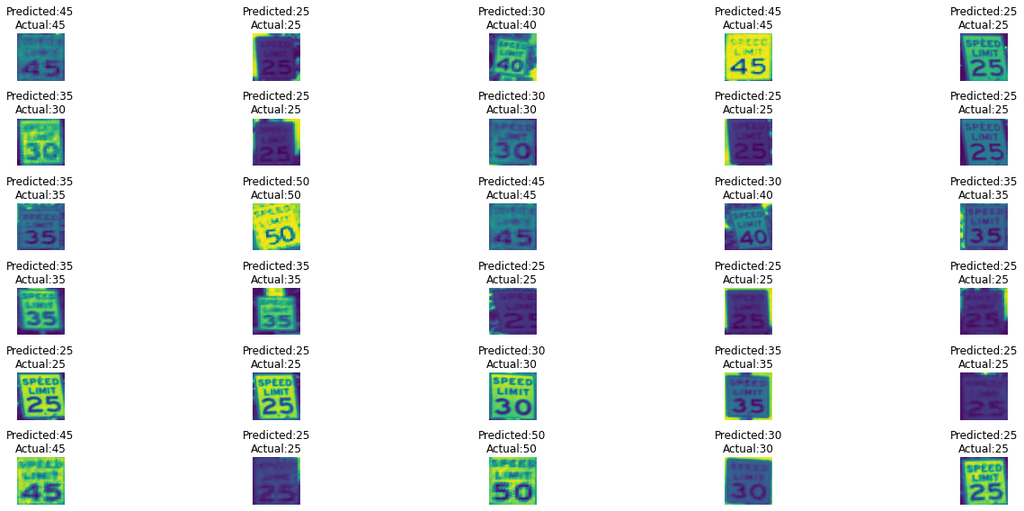

```python
import random
import cv2
from utils import Preprocess

data_dir = '/content/dir/MyDrive/4152 5152 Group Work/data/'

dataset = Preprocess.loadDataset(image_dims=[64,64])

del dataset['all']
del dataset['classed']
del dataset['60']
del dataset["speed limit signs"]

# Split dataset
train_pct = 0.7
test_pct = 0.1
valid_pct = 0.2
train_data, test_data, valid_data = Preprocess.split_dataset(dataset, train_pct, test_pct, valid_pct)


# Reshape data for use as inputs into the model
def reshape_data(data, image_shape=64):
  return np.reshape(data, [-1, image_shape, image_shape])


cols = 5
rows = 6

random_images = random.choices(test_data, k=cols*rows)


fig, axs = plt.subplots(rows, cols, figsize=(20,8))

labels = [25,30,35,40,45,50]
for i, image in enumerate(random_images):
  row = i // cols
  col =  i % cols

  yhat = model.predict(reshape_data(image['image']))

  axs[row, col].imshow(image['image'])
  axs[row, col].set_title(f"Predicted:{labels[np.argmax(np.round_(yhat))]}\nActual:{image['label']}")
  axs[row, col].axis('off')

fig.tight_layout()
```